# 10-02 in-class activity

Emily Beam

04-08-2021

## Getting Started

We’re going to dig deeper into the correlates of mobility by using [Opportunity Atlas](https://opportunityatlas.org/) to create some plots. We’re going to make a scatter plot!

1. Visit [Opportunity Atlas](https://opportunityatlas.org/) and search for the place you chose for your pre-class activity. If you no longer like this place, you can pick a new one.
2. Zoom in or out, as necessary, so that you get a “reasonable” geographic area that contains 30-50 census tracts (not a hard and fast rule, but each tract will be one data point).
3. Click on “Download the data” at the bottom right-hand corner.
- You want to download “Just what is on the screen.” If this option is not available, make sure you select “Single Subgroup.”
- You can pick “all” or select a specific subgroup, but I wouldn’t recommend any group that leads to a lot of grey tracts.
- I recommend you stick with “household income” as your outcome variable, but feel free to select a different outcome variable.
4. Get all your options set up and download the data set.
5. Pick a second variable you want to correlate with your first variable, and download that in the same way. I recommend “Job growth rate from 2004 to 2013” or “Density of Jobs in 2013.” You want the first to be an “outcome” and the second to be a “neighborhood characteristic.”

**In any case, I’d recommend you pick the same variables as your groupmates, so when you compare graphs it makes sense!**

## Loading data

Make sure your data files are in the right working directory. You may need to adjust the names.

```r
# Import outcome 1 and save as a df

income <- read_csv("shown_tract_kfr_rP_gP_pall.csv")

# Import outcome 2 and save as a df

jobdensity <- read_csv("shown_tract_job_density_2013.csv")
```

Take a look at your data (change names if you renamed your data frames!)

```r
income
```

```
## # A tibble: 192 x 3
##          tract Name                                   Household_Income_rP_gP_pa…
##          <dbl> <chr>                                                       <dbl>
##  1 26125151000 Bloomfield Village, Bloomfield Hills,…                      83217
##  2 26125152700 Birmingham, MI                                              80100
##  3 26125152000 Bloomfield Hills, MI                                        79472
##  4 26125196600 Troy, MI                                                    77675
##  5 26125196800 Troy, MI                                                    76962
##  6 26125152600 Birmingham, MI                                              76088
##  7 26125137400 Novi, MI                                                    75867
##  8 26125188000 Huntington Woods, MI                                        75791
##  9 26125167900 Farmington Hills, MI                                        75691
## 10 26125196700 Troy, MI                                                    75441
## # … with 182 more rows
```

```r
jobdensity
```

```
## # A tibble: 192 x 3
##          tract Name                                   Density_of_Jobs_in_2013
##          <dbl> <chr>                                                    <dbl>
##  1 26125183500 Royal Oak, MI                                            25093
##  2 26125161600 Southfield City Centre, Southfield, MI                   19750
##  3 26125162200 Southfield, MI                                           14799
##  4 26125197600 Troy, MI                                                 13947
##  5 26125162100 Southfield, MI                                           11899
##  6 26125160900 Southfield, MI                                           10492
##  7 26125160300 Southfield, MI                                            8745
##  8 26125153200 Birmingham, MI                                            8652
##  9 26163556500 Livonia, MI                                               7584
## 10 26125197701 Troy, MI                                                  7236
## # … with 182 more rows
```

```r
merged_data <- full_join(by = c("tract", "Name"), income, jobdensity)
merged_data
```

```
## # A tibble: 192 x 4
##         tract Name                     Household_Income_rP_… Density_of_Jobs_in…
##         <dbl> <chr>                                    <dbl>               <dbl>
##  1    2.61e10 Bloomfield Village, Blo…                 83217               476.
##  2    2.61e10 Birmingham, MI                           80100               386.
##  3    2.61e10 Bloomfield Hills, MI                     79472              1160
##  4    2.61e10 Troy, MI                                 77675               457.
##  5    2.61e10 Troy, MI                                 76962              3838
##  6    2.61e10 Birmingham, MI                           76088              1316
##  7    2.61e10 Novi, MI                                 75867                59.4
##  8    2.61e10 Huntington Woods, MI                     75791               671.
##  9    2.61e10 Farmington Hills, MI                     75691                82
## 10    2.61e10 Troy, MI                                 75441              1296
## # … with 182 more rows
```

# Exploratory analysis

A simple way to look at the relationship between two variables is to calculate a correlation coefficent. Here, I do it using Base R. There are other ways to do this as well. But, this gives us one number, and not a ton of information.

(Note that you’ll need to change the variable names to match yours!)

```r
cor.test(merged_data$Household_Income_rP_gP_pall, merged_data$Density_of_Jobs_in_2013,method="pearson")
```

```
##
##  Pearson's product-moment correlation
##
## data:  merged_data$Household_Income_rP_gP_pall and merged_data$Density_of_Jobs_in_2013
## t = -2.4201, df = 190, p-value = 0.01646
## alternative hypothesis: true correlation is not equal to 0
## 95 percent confidence interval:
##  -0.30701848 -0.03210642
## sample estimates:
##        cor
## -0.1729285
```

Let’s instead make a scatter plot:

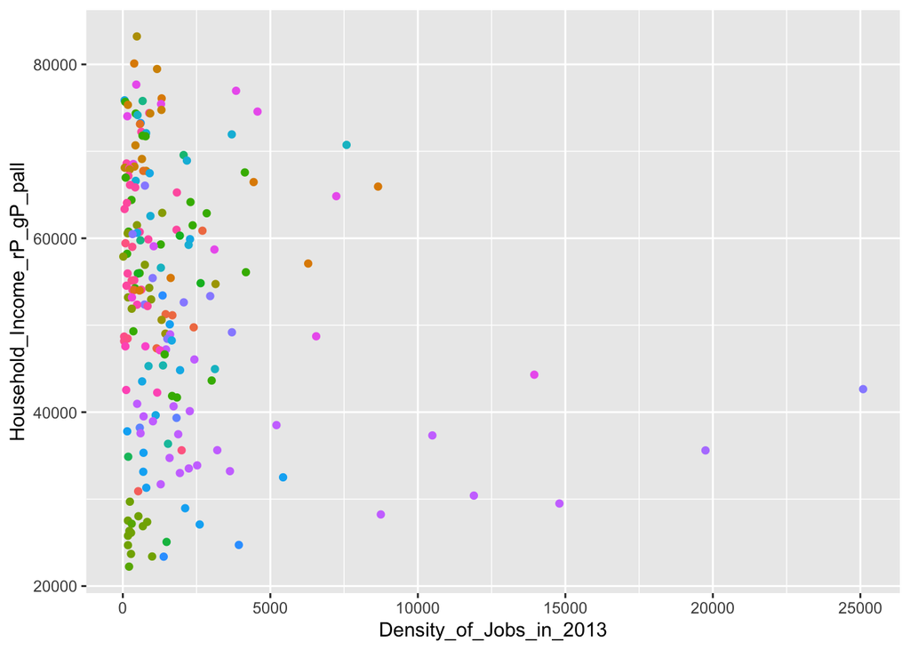

```r
  ggplot(data = merged_data, mapping = aes(y = Household_Income_rP_gP_pall, x = Density_of_Jobs_in_2013, color=Name )) +
      geom_point(show.legend=FALSE)
```

You may want to play around with the scale if you get a lot of bunching. For density of jobs, for example, it looks a lot better if I take a log.

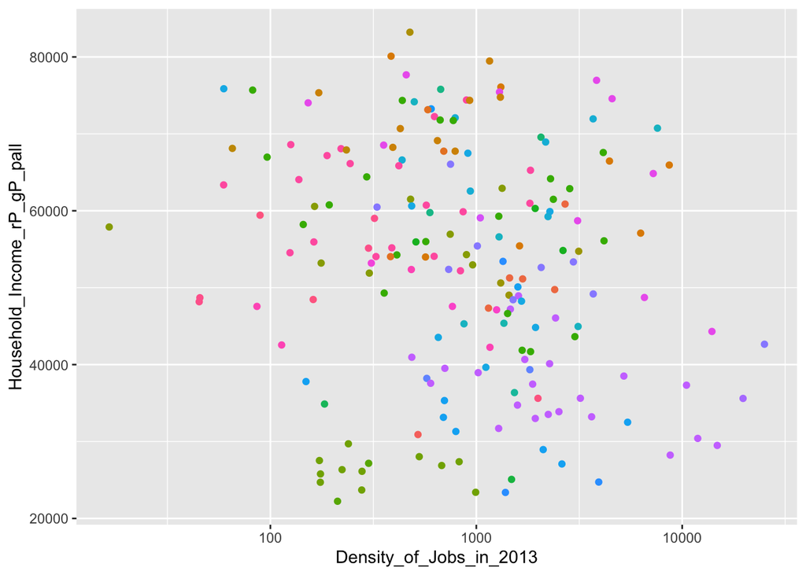

```r
  ggplot(data = merged_data, mapping = aes(y = Household_Income_rP_gP_pall, x = Density_of_Jobs_in_2013, color=Name )) +
      geom_point(show.legend=FALSE) +
  scale_x_log10()
```

What if you want to estimate a line of best fit? This is regression land, but we can give it a go. Notice here that I moved `color=Name` out of the main ggplot and into `geom_point` only. The idea is that I want to color my points based on city, but I don’t want separate regression lines per city. You can play w/ moving arguments around to see how it does or does not make a difference.

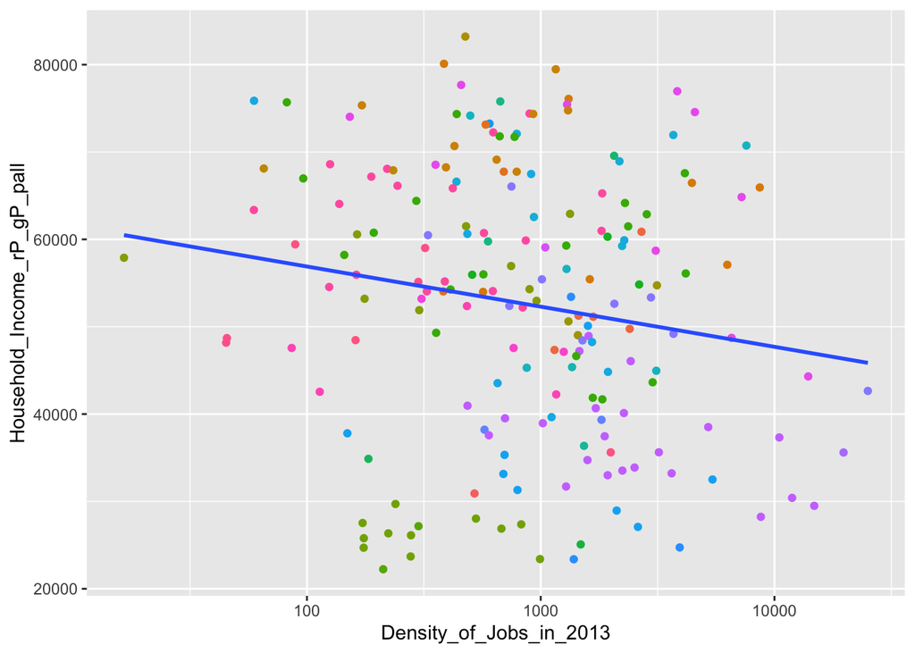

```r
  ggplot(data = merged_data, mapping = aes(y = Household_Income_rP_gP_pall, x = Density_of_Jobs_in_2013,  )) +
      geom_point(aes(color=Name), show.legend=FALSE) +
    geom_smooth(method=lm, se =FALSE, show.legend=FALSE) +
    scale_x_log10()
```

# All done!

1. Share w/ your group mates. You can paste in your chat or in your shared Google doc.
2. Knit and upload. If you’ve got some time, format that graph.